# Actividad 1.8

#### 6. Haz el análisis factorial usando el criterio de máxima verosimilitud y el de mínimo residuo.

```r
modelo1 = fa(M, nfactors =2, rotate = "none", fm = "mle")   # de máxima verosimilitud
modelo2 = fa(M, nfactors = 2, rotate = "none", fm = "minres") # Modelo de mínimo residuo
cat("Criterio de máxima verosimilitud \n")
```

```
## Criterio de máxima verosimilitud
```

```r
print(modelo1, cut = 0.3)
```

```
## Factor Analysis using method =  ml
## Call: fa(r = M, nfactors = 2, rotate = "none", fm = "mle")
## Standardized loadings (pattern matrix) based upon correlation matrix
##               ML1   ML2   h2    u2 com
## Tamano       0.98       0.96 0.044 1.0
## Temperatura       -0.60 0.40 0.604 1.2
## Proteinas    0.60  0.64 0.77 0.229 2.0
## Oxigeno     -0.32 -0.33 0.21 0.793 2.0
## LnProteinas  0.87  0.40 0.92 0.082 1.4
## LnTamano     1.00       1.00 0.005 1.0
##
##                        ML1  ML2
## SS loadings           3.21 1.04
## Proportion Var        0.53 0.17
## Cumulative Var        0.53 0.71
## Proportion Explained  0.76 0.24
## Cumulative Proportion 0.76 1.00
##
## Mean item complexity =  1.4
## Test of the hypothesis that 2 factors are sufficient.
##
## df null model =  15  with the objective function =  6.47 with Chi Square =  557.86
## df of  the model are 4  and the objective function was  0.52
##
## The root mean square of the residuals (RMSR) is  0.06
## The df corrected root mean square of the residuals is  0.11
##
## The harmonic n.obs is  90 with the empirical chi square  4.65  with prob <  0.33
## The total n.obs was  90  with Likelihood Chi Square =  43.94  with prob <  6.6e-09
##
## Tucker Lewis Index of factoring reliability =  0.72
## RMSEA index =  0.333  and the 90 % confidence intervals are  0.25 0.428
## BIC =  25.94
## Fit based upon off diagonal values = 0.99
## Measures of factor score adequacy
##                                                    ML1  ML2
## Correlation of (regression) scores with factors   1.00 0.91
## Multiple R square of scores with factors          1.00 0.82
## Minimum correlation of possible factor scores     0.99 0.65
```

```r
cat("\nCriterio de mínimo residuo \n")
```

```
##
## Criterio de mínimo residuo
```

```r
print(modelo2, cut = 0.3) #Muestra solo las cargas mayores a 0.3 (las más importantes)
```

```
## Factor Analysis using method =  minres
## Call: fa(r = M, nfactors = 2, rotate = "none", fm = "minres")
## Standardized loadings (pattern matrix) based upon correlation matrix
##               MR1   MR2   h2    u2 com
## Tamano       0.96       0.97 0.025 1.1
## Temperatura        0.92 0.85 0.155 1.0
## Proteinas    0.73       0.60 0.397 1.3
## Oxigeno     -0.40  0.35 0.28 0.716 2.0
## LnProteinas  0.94       0.90 0.097 1.0
## LnTamano     0.93       0.92 0.076 1.1
##
##                        MR1  MR2
## SS loadings           3.37 1.16
## Proportion Var        0.56 0.19
## Cumulative Var        0.56 0.76
## Proportion Explained  0.74 0.26
## Cumulative Proportion 0.74 1.00
##
## Mean item complexity =  1.3
## Test of the hypothesis that 2 factors are sufficient.
##
## df null model =  15  with the objective function =  6.47 with Chi Square =  557.86
## df of  the model are 4  and the objective function was  0.92
##
## The root mean square of the residuals (RMSR) is  0.03
## The df corrected root mean square of the residuals is  0.06
##
## The harmonic n.obs is  90 with the empirical chi square  1.14  with prob <  0.89
## The total n.obs was  90  with Likelihood Chi Square =  77.79  with prob <  5.1e-16
##
## Tucker Lewis Index of factoring reliability =  0.482
## RMSEA index =  0.453  and the 90 % confidence intervals are  0.37 0.546
## BIC =  59.79
## Fit based upon off diagonal values = 1
## Measures of factor score adequacy
##                                                    MR1  MR2
## Correlation of (regression) scores with factors   0.99 0.94
## Multiple R square of scores with factors          0.98 0.88
## Minimum correlation of possible factor scores     0.96 0.75
```

```r
M1_commd = c(modelo1$communality, modelo1$uniquenesses)
M2_commd= c(modelo2$communality, modelo2$uniquenesses)
T_ = data.frame(M1_commd,M2_commd)
T_
```

```
##       M1_commd   M2_commd
## 1  0.955828349 0.97481762
## 2  0.396325401 0.84539959
## 3  0.770838338 0.60296446
## 4  0.207102929 0.28354756
## 5  0.918123048 0.90305533
## 6  0.995045486 0.92385822
## 7  0.044171651 0.02518238
## 8  0.603674599 0.15460041
## 9  0.229161662 0.39703554
## 10 0.792897071 0.71645244
## 11 0.081876952 0.09694467
## 12 0.004954514 0.07614178
```

Tamano, LnTamano, LnProteinas y Proteinas quedan muy bien explicadas por el modelo en ambos métodos. Las comunalidades altas indican que casi toda su varianza es compartida con los factores. Temperatura es la variable en la que los métodos más discrepan. Con el modelo de mínimo residuo tiene comunalidad 0.85 y define casi por sí sola el factor 2 (carga 0.92). Con máxima verosimilitud la comunalidad baja a 0.40 y el factor 2 mezcla Temperatura con un contraste frente a Proteinas. Esto es coherente con su KMO individual de 0.41, el más bajo de todas las variables.

#### 7. Realicen los gráficos correspondientes a la rotación Varimax y quartimax de los datos e interpreten en equipo los resultados.

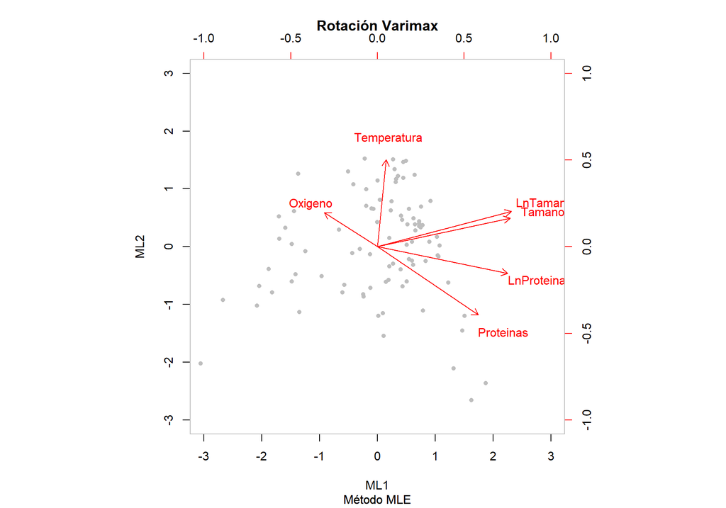

```r
modelo1V = fa(M, nfactors = 2, rotate = "varimax", fm = "mle")
biplot.psych(modelo1V, main="Rotación Varimax", sub="Método MLE", col=c("gray","red"))
```

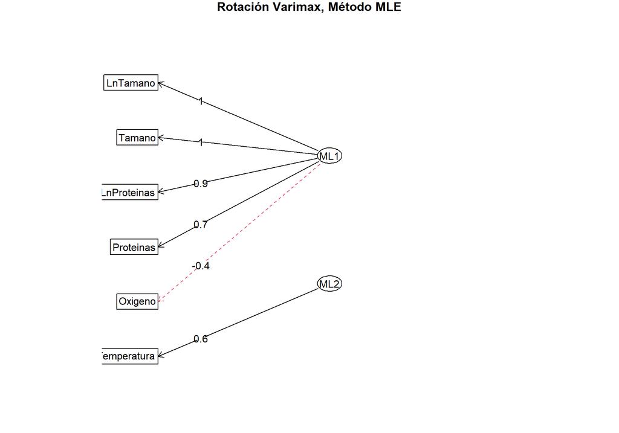

```r
fa.diagram(modelo1V, main="Rotación Varimax, Método MLE")
```

```r
print(modelo1V$loadings, cut=0.3)
```

```
##
## Loadings:
##             ML1    ML2
## Tamano       0.956
## Temperatura         0.626
## Proteinas    0.727 -0.493
## Oxigeno     -0.383
## LnProteinas  0.939
## LnTamano     0.964
##
##                  ML1   ML2
## SS loadings    3.404 0.839
## Proportion Var 0.567 0.140
## Cumulative Var 0.567 0.707
```

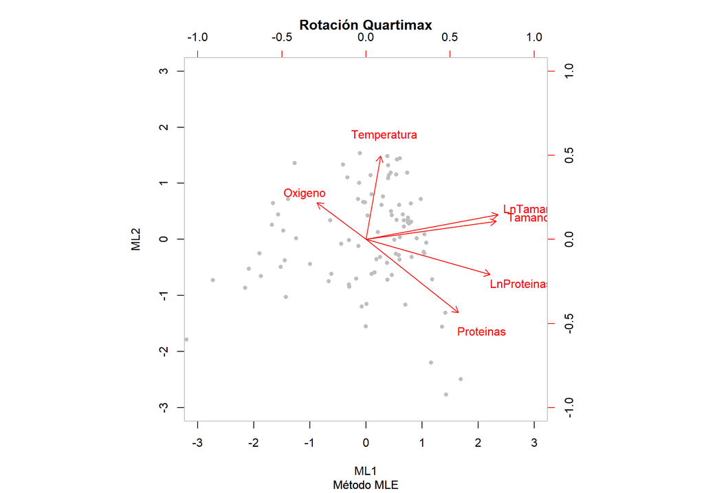

```r
modelo1Q <- fa(M, nfactors = 2, rotate = "quartimax", fm = "mle")
biplot.psych(modelo1Q, main = "Rotación Quartimax", sub = "Método MLE", col = c("gray","red"))
```

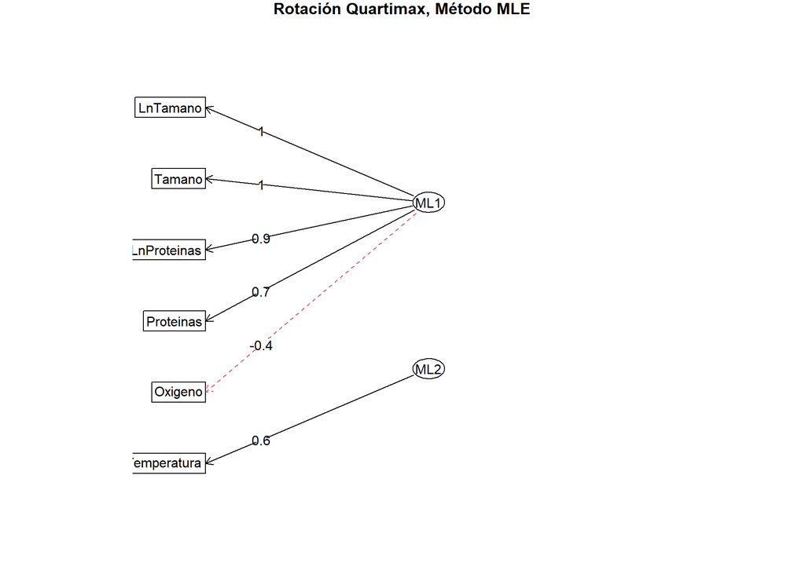

```r
fa.diagram(modelo1Q, main = "Rotación Quartimax, Método MLE")
```

```r
print(modelo1Q$loadings, cut = 0.3)
```

```
##
## Loadings:
##             ML1    ML2
## Tamano       0.969
## Temperatura         0.620
## Proteinas    0.688 -0.545
## Oxigeno     -0.364
## LnProteinas  0.922
## LnTamano     0.981
##
##                  ML1   ML2
## SS loadings    3.368 0.876
## Proportion Var 0.561 0.146
## Cumulative Var 0.561 0.707
```

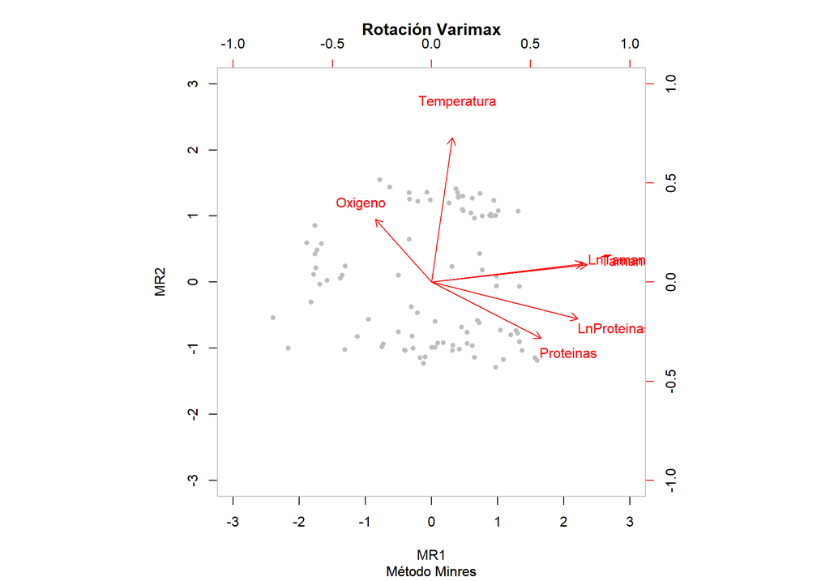

```r
modelo2V <- fa(M, nfactors = 2, rotate = "varimax",   fm = "minres")
biplot.psych(modelo2V, main="Rotación Varimax", sub="Método Minres", col=c("gray","red"))
```

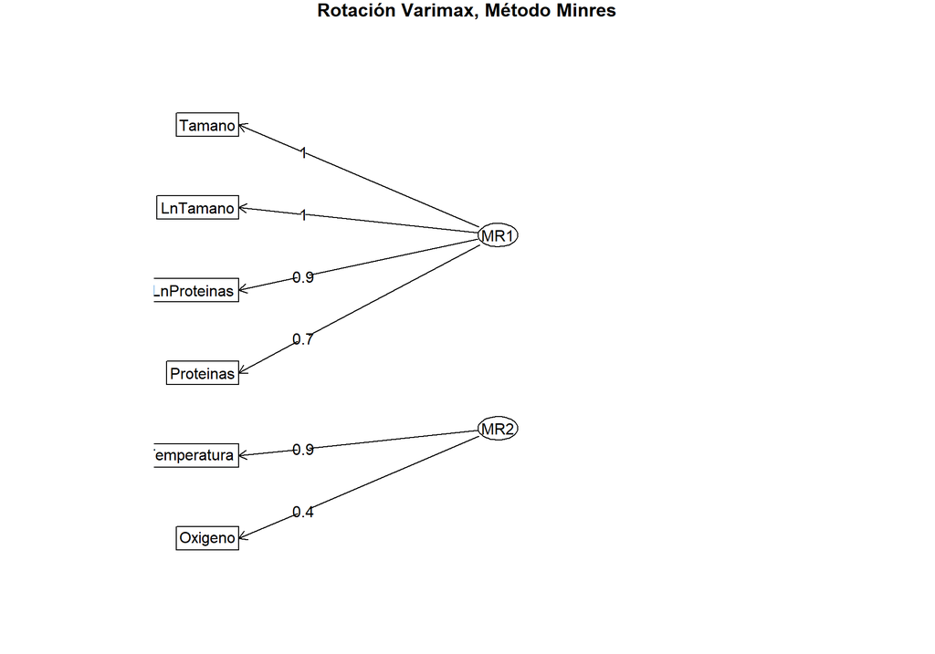

```r
fa.diagram(modelo2V, main="Rotación Varimax, Método Minres")
```

```r
print(modelo2V$loadings, cut = 0.3)
```

```
##
## Loadings:
##             MR1    MR2
## Tamano       0.981
## Temperatura         0.910
## Proteinas    0.691 -0.354
## Oxigeno     -0.355  0.397
## LnProteinas  0.922
## LnTamano     0.954
##
##                  MR1   MR2
## SS loadings    3.343 1.190
## Proportion Var 0.557 0.198
## Cumulative Var 0.557 0.756
```

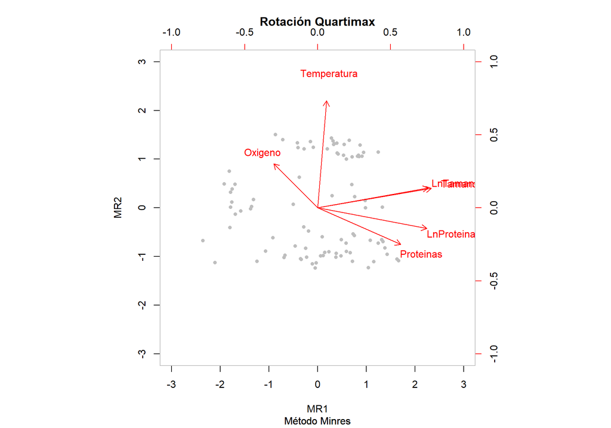

```r
modelo2Q <- fa(M, nfactors = 2, rotate = "quartimax", fm = "minres")
biplot.psych(modelo2Q, main = "Rotación Quartimax", sub = "Método Minres", col = c("gray","red"))
```

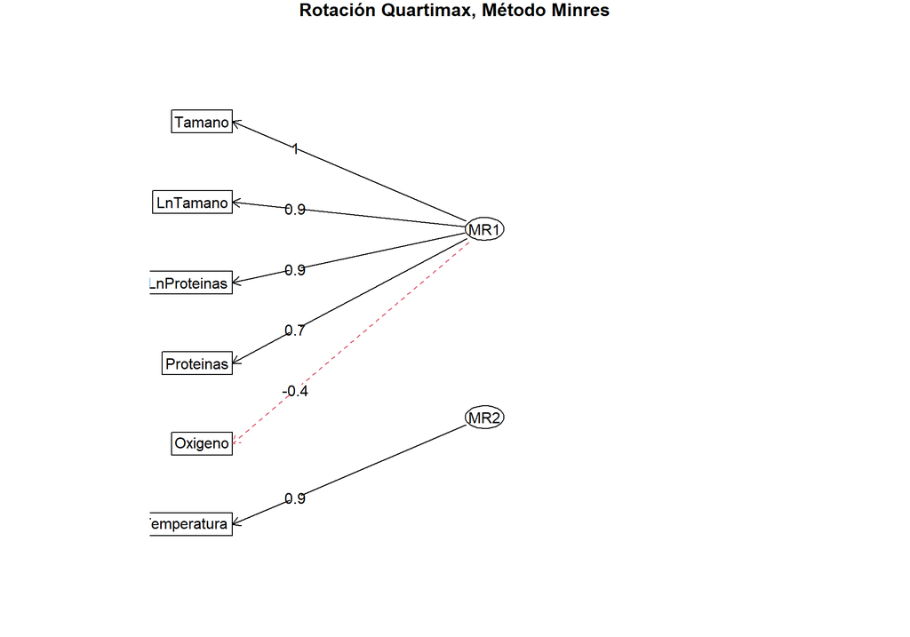

```r
fa.diagram(modelo2Q, main = "Rotación Quartimax, Método Minres")
```

```r
print(modelo2Q$loadings, cut = 0.3)
```

```
##
## Loadings:
##             MR1    MR2
## Tamano       0.973
## Temperatura         0.916
## Proteinas    0.710 -0.314
## Oxigeno     -0.377  0.376
## LnProteinas  0.934
## LnTamano     0.946
##
##                  MR1   MR2
## SS loadings    3.366 1.167
## Proportion Var 0.561 0.195
## Cumulative Var 0.561 0.756
```

#### 8. ¿Qué pueden concluir? ¿Resultó razonable para este caso el modelo de análisis factorial? ¿Cuál modelo resulta más convincente? Expliquen.

Sí es razonable el modelo de análisis factorial, aunque con ciertos detalles. Bartlett es significativo, Cattell y el análisis paralelo coinciden en 2 factores, los 2 factores explican gran cantidad de la varianza, y la estructura es interpretable como productividad (tamaño y proteínas) y hábitat (temperatura y oxígeno). Sin embargo, el KMO global es 0.63, apenas aceptable, y el de Temperatura es 0.41, así como también las variables Ln son transformaciones de las originales. Eso infla el Factor 1 de forma artificial: en la práctica hay 4 variables que miden 2 cosas, tamaño y proteínas. Una reespecificación más limpia sería usar solo las variables originales o solo las logarítmicas.

Con respecto a cuál modelo es más convincente, este debe ser el de mínimo residuo, ya que explica más varianza (76% frente a 71%) y tiene un residuo menor (RMSR 0.03 frente a 0.06); además, representa mejor a Temperatura (comunalidad 0.85 frente a 0.40) y da una estructura más simple en F2. Aun así, ningún modelo alcanza un ajuste aceptable por RMSEA, por lo que la conclusión es que 2 factores resumen bien la estructura general, pero el modelo no es completamente satisfactorio.

## Declaratoria de uso de IA durante el desarrollo del trabajo

Se utilizó IA:

1. Herramienta: Gemini y Claude
2. Uso realizado: Ayuda en el código a lo largo de la tarea, así como también en la redacción y guía en las interpretaciones
3. Secciones donde se utilizó: Código en el inciso 7 para las gráficas, así como también ayuda en redacció, formato e inetrpretación a lo largo del documento.
4. Validación realizada por los estudiantes: Se verificó, corrió y depuró todo el script de R, así como también analizaron todos los resultados arrojados para validar que todo estuviera correcto y en orden.
5. Confirmo de que se revisó, verificó y que se asume la responsabilidad del contenido final entregado.